# simulations_v1

Raine Detmer

2023-07-26

First attempt at simulating data with a known driver-response relationship and seeing whether a threshold in this relationship can be detected by GAMs

# Setup

Load functions for simulating data, fitting GAMs, calculating thresholds, etc. :

```r
source("load_functions.R") # loads all the functions in the "functions" folder
```

The functions for fitting GAMs, bootstrapping, and calculating thresholds are copied/modified from the “SICCME/S-CCME Tipping Points ECCWO5 Workshop” by K. Holsman, K. Mills, E. Hazen (https://github.com/kholsman/Tipping-Points)

# Example driver-response relationship

Use a driver-response relationship that is similar to the relationship between Ca. sea lion pup production and NOI_summer (Fig. 4a of Samhouri et al. 2017). To get a rough analytical approximation of this type of relationship, make some fake data that resemble the curve in Fig. 4a, and then fit a nonlinear function to these data:

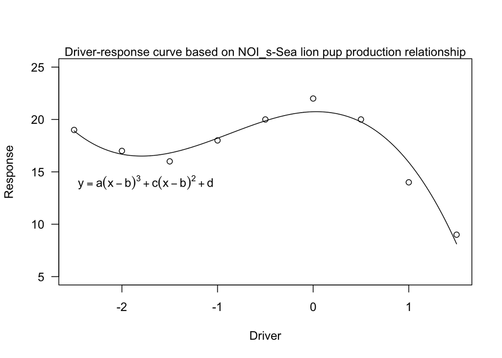

```r
fakedt <- data.frame(
  pups = c(19, 17, 16, 18, 20, 22, 20, 14, 9),
  nois = c(-2.5, -2, -1.5, -1, -0.5, 0, 0.5, 1, 1.5)
)

# use nls() to fit a curve to these data
mod1 <- nls(pups~ a*(nois-b)^3 + c*(nois-b)^2 +d, data = fakedt, start = list(a = 1, b = 0.1, c = 1, d = 18)) # try cubic polynomial with x^2 term (which means the second deriv should be a line with a nonzero x-intercept)

# save the coefficients
a <- summary(mod1)$coefficients[1, 1]
b <- summary(mod1)$coefficients[2, 1]
c <- summary(mod1)$coefficients[3, 1]
d <- summary(mod1)$coefficients[4, 1]

# plot results
plot(x = fakedt$nois, y = fakedt$pups, xlab = "Driver", ylab = "Response", las=1, ylim = c(5, 25))
lines(x = seq(from = -2.5, to = 1.5, length.out = 1000), y = a*(seq(from = -2.5, to = 1.5, length.out = 1000)-b)^3 + c*(seq(from = -2.5, to = 1.5, length.out = 1000)-b)^2 + d, type = "l")
text(x = -1.75, y = 14, expression(y==a(x-b)^3 + c(x-b)^2 + d))#"y = a(x-b)^3 + c(x-b)^2 + d"
mtext(side = 3, "Driver-response curve based on NOI_s-Sea lion pup production relationship")
```

turn this into a function to use for simulating data:

```r
true_yofx <- function(x.f){ # input = value of the driver
  y <- a*(x.f-b)^3+c*(x.f-b)^2+d

  return(y) # return value of response
}
```

The first derivative of this function is

$$\frac{dy}{dt} = 3a(x-b)^2 +
2c(x-b)$$

and the second derivative is

$$\frac{d^2y}{dt^2} =
6a(x-b)+2c$$

The true threshold (as defined by the inflection point) is where the second derivative is equal to zero, which occurs when x = b - c/(3a)

```r
thresh_true <- b - c/(3*a)
```

# Simulations

## Driver data

use summary statistics from the real data on NOI_summer for simulating values of the driver

```r
# import the NOI data
noi <- read.csv("https://oceanview.pfeg.noaa.gov/erddap/tabledap/cciea_OC_NOI.csv?time%2CNOI%2Cindex&index=%22NOI%22")

#View(noi)

noi1 <- noi[-1,] # remove header row

# calculate the values of NOI in the summer (here I took the mean across months 7, 8, and 9, but not sure if this is the correct way to calculate summer NOI)
nois <- noi1 %>% mutate(year = lubridate::year(time), month =lubridate::month(time)) %>% mutate(NOI = as.numeric(NOI)) %>% mutate(season = if_else(month %in% c(7, 8, 9), "S", if_else(month %in% c(1, 2,3), "W", "NA"))) %>% filter(season=="S") %>% group_by(year) %>% summarize(NOI = mean(NOI, na.rm = T))

# get the mean and sd
nois_mean <- mean(nois$NOI, na.rm = T)
nois_sd <- sd(nois$NOI, na.rm = T)

# check for autocorrelation
#acf(nois$NOI)
```

## Parameters

define parameters for the simulations and fitting

```r
nsim1 <- 1 #number of simulations to run
tmax <- 60 # max length of simulated time series
x_mean <- nois_mean# mean of x variable (driver)
x_sd <- nois_sd #sd of x variable
x_acf <- 0 #temporal autocorrelation of x variable
xy_fun <- true_yofx #function for true relationship between driver and response
p_error <- 0.1 #process error (noise in relationship between x and y)
obs_error <- 0.1#observation error (noise in observation of y values)
seed <- 123 #seed for random number generation
y_pos <- TRUE # restrict x values to those that produce positive y values (see sim1fun.R for details; issue is that the true_yofx function used here predicts negative y values for x > around 1.8, which doesn't make sense if y = number of pups produced. I cheated by restricting the x domain but the true_yofx function should probably be changed)
x_min <- -Inf # no minimum x value
x_max <- 1.8 # max x value; if simulated values are larger than this they are set to 1.8

knots <- 4 # knots for GAMS; set to 4 in Holsman et al. 2020
xvals <- seq(from = -3, to= 1.8, by = 0.05) # values of the driver to use for GAM predictions
boot_n <- 500 # number of bootstraps to run
boot_nobs <- 45 # number of samples to take each bootstrap run

sdmult <- 1 # 1 sd (involved in calculating threshold significance)
method <- 2  # method for getting the threshold significance; Holsman et al. 2020 used method 2
prob <- c(0.025,0.5,0.975) # probabilities for the quantile ranges
span <- 0.1  # smoothing step/span for thresholds; 0.1 is default in Holsman et al. 2020
```

## Test simulation and fitting

Start with low observation error and a long time series to see how well the GAMs can predict the relationship between x and y and the value of the threshold

Test 3 different approaches to calculating the threshold: 1) threshold = point where first deriv is both significantly different from zero and at a max or min value, 2) threshold = point where second deriv is both significantly different from zero and at a max or min value (used in Large et al. 2013 and Samhouri et al. 2017), and 3) threshold = point where second deriv is closest to zero

```r
# simulate the data (see sim1fun.R for details)
simtest1 <- simfun1(nsim1, tmax, x_mean, x_sd, x_acf, xy_fun, p_error, obs_error, seed, y_pos, x_max, x_min)

# fit a GAM to the simulated data (see gamfun.R for details)
gamtest1 <- gamfun(nsim1, simtest1, knots, xvals)

# do the bootstrapping to get the quantiles and first and second derivs (see bootfun.R for details)
boottest1 <- bootfun(nsim1, simtest1, knots, boot_n, boot_nobs, xvals)

# calculate the values of the threshold using the three approaches described above (see threshfun.R for details)
threshtest1 <- threshfun(nsim1, gamtest1, boottest1, xvals, sdmult, method, prob, span)
```

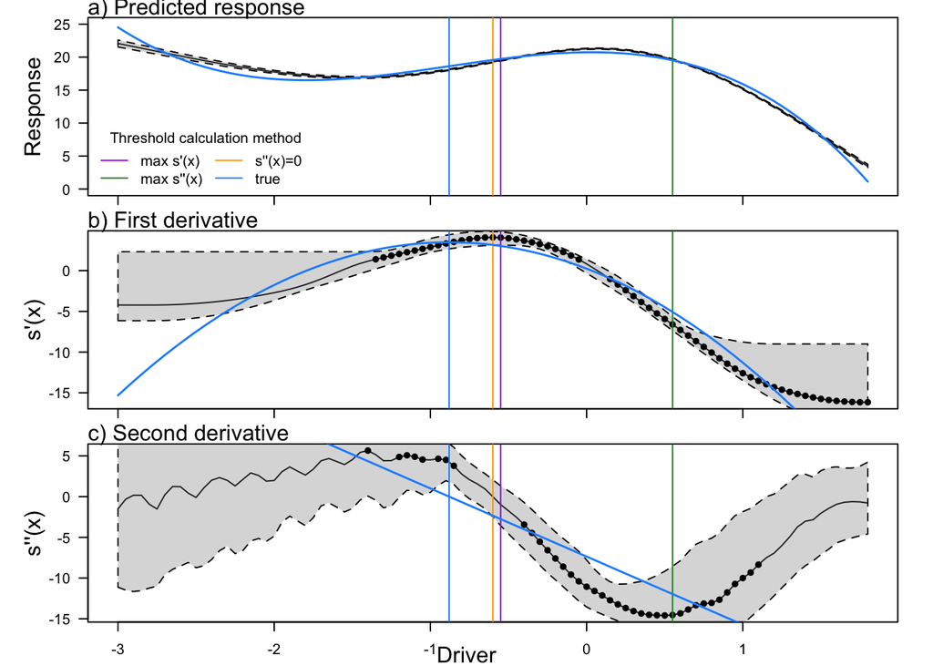

```r
# plot the smoothed predictions

i <- 1 # first simulation
par(mfrow = c(3, 1), mar = c(1, 5, 1, 2), oma = c(1.5, 0, 0, 0))
plot(x = threshtest1$hat_qnts[[i]]$driver, y = threshtest1$hat_qnts[[i]]$smoothed_mn, type = "l", xlab = NA, ylab = NA, ylim = c(0, 25), las = 1, xaxt = "n")
mtext(side = 3, "a) Predicted response", adj = 0)
mtext(side = 2, "Response", line = 2.5)
axis(side = 1, at = c(-3, -2, -1, 0, 1), labels = NA)
# add the confidence intervals
polygon(x = c(threshtest1$hat_qnts[[i]]$driver, rev(threshtest1$hat_qnts[[i]]$driver)), y = c(threshtest1$hat_qnts[[i]]$smoothed_dwn, rev(threshtest1$hat_qnts[[i]]$smoothed_up)), col = adjustcolor("gray50", alpha.f = 0.3), lty = 2)
# threshold using max first deriv
abline(v =threshtest1$thresh_1[[i]], col = "purple")
# threshold using max second deriv
abline(v =threshtest1$thresh_2[[i]], col = "forestgreen")
# threshold using second deriv closest to 0
abline(v =threshtest1$thresh_20[[i]], col = "orange")
# add true values
lines(x = xvals, y =true_yofx(xvals), type = "l", lty = 1, col = "dodgerblue", lwd = 1.5)
abline(v = thresh_true, col = "dodgerblue", lwd = 1, lty = 1) # true threshold
#legend(x = "left", legend = c("GAM prediction", "true value"), col = c("black", "dodgerblue"), bty = "n", lwd = 1, ncol = 2)
legend(x = "bottomleft", legend = c("max s'(x)", "max s''(x)", "s''(x)=0", "true"), title = "Threshold calculation method", col = c("purple", "forestgreen", "orange", "dodgerblue"), lty = 1, bty = "n", ncol = 2)

# plot the smoothed first derivative
plot(x = threshtest1$df1_qnts[[i]]$driver, y = threshtest1$df1_qnts[[i]]$smoothed_mn, type = "l", xlab = NA, ylab = NA, las = 1, xaxt = "n")
mtext(side = 3, "b) First derivative", adj = 0)
mtext(side = 2, "s'(x)", line = 2.5)
axis(side = 1, at = c(-3, -2, -1, 0, 1), labels = NA)
# add the confidence intervals
polygon(x = c(threshtest1$df1_qnts[[i]]$driver, rev(threshtest1$df1_qnts[[i]]$driver)), y = c(threshtest1$df1_qnts[[i]]$smoothed_dwn, rev(threshtest1$df1_qnts[[i]]$smoothed_up)), col = adjustcolor("gray50", alpha.f = 0.3), lty = 2)
# add location where derivative is significantly different from zero (where sig = TRUE)
lines(x = threshtest1$df1_qnts[[i]]$driver[which(threshtest1$df1_qnts[[i]]$sig)], y = threshtest1$df1_qnts[[i]]$smoothed_mn[which(threshtest1$df1_qnts[[i]]$sig)], type = "p", pch = 16)
# threshold using max first deriv
abline(v =threshtest1$thresh_1[[i]], col = "purple")
# threshold using max second deriv
abline(v =threshtest1$thresh_2[[i]], col = "forestgreen")
# threshold using second deriv closest to 0
abline(v =threshtest1$thresh_20[[i]], col = "orange")
# add true values
lines(x = xvals, y = 3*a*(xvals-b)^2 + 2*c*(xvals-b), type = "l", lty = 1, col = "dodgerblue", lwd = 1.5)
abline(v = thresh_true, col = "dodgerblue", lwd = 1, lty = 1) # true threshold

# plot the smoothed second derivative
plot(x = threshtest1$df2_qnts[[i]]$driver, y = threshtest1$df2_qnts[[i]]$smoothed_mn, type = "l", xlab = NA, ylab = NA, las = 1)
mtext(side = 3, "c) Second derivative", adj = 0)
mtext(side = 2, "s''(x)", line = 2.5)
mtext(side = 1, "Driver", line = 0.5, outer = TRUE)
# add the confidence intervals
polygon(x = c(threshtest1$df2_qnts[[i]]$driver, rev(threshtest1$df2_qnts[[i]]$driver)), y = c(threshtest1$df2_qnts[[i]]$smoothed_dwn, rev(threshtest1$df2_qnts[[i]]$smoothed_up)), col = adjustcolor("gray50", alpha.f = 0.3), lty = 2)
# add location where derivative is significantly different from zero (where sig = TRUE)
lines(x = threshtest1$df2_qnts[[i]]$driver[which(threshtest1$df2_qnts[[i]]$sig)], y = threshtest1$df2_qnts[[i]]$smoothed_mn[which(threshtest1$df2_qnts[[i]]$sig)], type = "p", pch = 16)
# threshold using max first deriv
abline(v =threshtest1$thresh_1[[i]], col = "purple")
# threshold using max second deriv
abline(v =threshtest1$thresh_2[[i]], col = "forestgreen")
# threshold using second deriv closest to 0
abline(v =threshtest1$thresh_20[[i]], col = "orange")
# add true values
lines(x = xvals, y = 6*a*(xvals-b) + 2*c, type = "l", lty = 1, col = "dodgerblue", lwd = 1.5)
abline(v = thresh_true, col = "dodgerblue", lwd = 1, lty = 1) # true threshold
```

In the above figure, the black lines and gray shading are the smoothed mean and 95% quantiles, respectively, of a) the GAM predictions, b) the first derivative, and c) the second derivative. Black dots indicate where the derivatives are significantly different from zero. The light blue curves are the true values for a) the response, b) the first derivative, and c) the second derivative.

The vertical lines indicate threshold values, where light blue = true threshold, purple = threshold calculated as location where first deriv is at a max/min and significantly different from zero, green = threshold calculated as location where second deriv is at a max/min and significantly different from zero, and orange = threshold calculated as location where second deriv is closest to zero

## Effects of timeseries length and observation error

Do a quick test of the effects of time series length and observation error on threshold detectability

```r
# set of time series lengths
length_set <- c(15, 30, 45, 60)

# set of observation errors
obs_set <- c(0.5, 3)

# number of simulations to run for each combination
nsim <- 10
```

```r
# run the simulations
# low obs error
sim_lowOE <- simfun1(nsim, tmax, x_mean, x_sd, x_acf, xy_fun, p_error, obs_set[1], seed, y_pos, x_max, x_min) # obs_error = obs_set[i]

# high obs error
sim_highOE <- simfun1(nsim, tmax, x_mean, x_sd, x_acf, xy_fun, p_error, obs_set[2], seed, y_pos, x_max, x_min)

# do the bootrapping and threshold calculations for different time series lengths
tic() # see how long this takes

# start with low obs error
# make holding lists to store all the results for each time series length
gam_lowOE <- vector(mode = "list", length = length(length_set)) # for outputs from gamfun
boot_lowOE <- vector(mode = "list", length = length(length_set)) # for outputs from bootfun
thresh_lowOE <- vector(mode = "list", length = length(length_set)) # for outputs from threshfun
threshdiff_lowOE <- vector(mode = "list", length = length(length_set)) # for output from threshdiff_fun (which returns a data frame that includes the number of thresholds detected and the difference between the estimated threshold and the true threshold; see threshdiff_fun.R for details)

for(i in 1:length(length_set)){

tmaxi <- length_set[i] # get the ith time series length

dtsub <- sim_lowOE[which(sim_lowOE$t<=tmaxi),] # subset the data to this number of observations

gami <- gamfun(nsim, sim_lowOE, knots, xvals)

booti <- bootfun(nsim, sim_lowOE, knots, boot_n, round(0.75*length_set[i]), xvals) # boot_nobs = round(0.75*ts length)

threshi <- threshfun(nsim, gami, booti, xvals, sdmult, method, prob, span)

threshdiffi <- threshdiff_fun(nsim, thresh_true, threshi, 1)

# store results
gam_lowOE[[i]] <- gami

boot_lowOE[[i]] <- booti

thresh_lowOE[[i]] <- threshi

threshdiff_lowOE[[i]] <- threshdiffi


}


# repeat for higher obs error
gam_highOE <- vector(mode = "list", length = length(length_set)) # for outputs from gamfun
boot_highOE <- vector(mode = "list", length = length(length_set)) # for outputs from bootfun
thresh_highOE <- vector(mode = "list", length = length(length_set)) # for outputs from threshfun
threshdiff_highOE <- vector(mode = "list", length = length(length_set)) # for outputs from threshdiff_fun


for(i in 1:length(length_set)){

tmaxi <- length_set[i]

dtsub <- sim_highOE[which(sim_highOE$t<=tmaxi),]

gami <- gamfun(nsim, sim_highOE, knots, xvals)

booti <- bootfun(nsim, sim_highOE, knots, boot_n, round(0.75*length_set[i]), xvals) # boot_nobs = round(0.75*ts length)

threshi <- threshfun(nsim, gami, booti, xvals, sdmult, method, prob, span)

threshdiffi <- threshdiff_fun(nsim, thresh_true, threshi, 1)

# store results
gam_highOE[[i]] <- gami

boot_highOE[[i]] <- booti

thresh_highOE[[i]] <- threshi

threshdiff_highOE[[i]] <- threshdiffi


}

toc()
```

```
## 761.822 sec elapsed
```

Plot results:

```r
# assign colors for each type of threshold calculation

threshcols <- c("purple", "forestgreen", "orange")

# assign point types for each type of threshold calculation
threshpch <- c(0, 1, 2)
```

First look at the effect of time series length and observation error on whether a threshold was detected

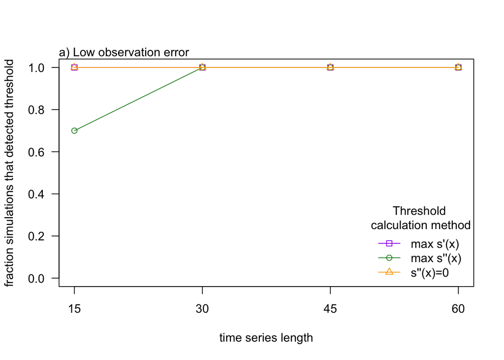

```r
# get the fraction of simulations that detected a threshold for each combination of time series length and obs error
# low observation error
nthresh1_totL <- c(sum(threshdiff_lowOE[[1]]$thresh1df$nthresh), sum(threshdiff_lowOE[[2]]$thresh1df$nthresh), sum(threshdiff_lowOE[[3]]$thresh1df$nthresh), sum(threshdiff_lowOE[[4]]$thresh1df$nthresh))/nsim

nthresh2_totL <- c(sum(threshdiff_lowOE[[1]]$thresh2df$nthresh), sum(threshdiff_lowOE[[2]]$thresh2df$nthresh), sum(threshdiff_lowOE[[3]]$thresh2df$nthresh), sum(threshdiff_lowOE[[4]]$thresh2df$nthresh))/nsim

nthresh20_totL <- c(sum(threshdiff_lowOE[[1]]$thresh20df$nthresh), sum(threshdiff_lowOE[[2]]$thresh20df$nthresh), sum(threshdiff_lowOE[[3]]$thresh20df$nthresh), sum(threshdiff_lowOE[[4]]$thresh20df$nthresh))/nsim

# plot the results
plot(x = length_set, y = nthresh1_totL, type = "o",pch = threshpch[1], ylim = c(0, 1), xaxt = "n", xlab = "time series length", ylab = "fraction simulations that detected threshold", las = 1, col = threshcols[1])
axis(side = 1, at = length_set, labels = length_set)
lines(x = length_set, y = nthresh2_totL, type = "o", pch = threshpch[2], col = threshcols[2])
lines(x = length_set, y = nthresh20_totL, type = "o", pch = threshpch[3], col = threshcols[3])
legend(x = "bottomright", legend = c("max s'(x)", "max s''(x)", "s''(x)=0"), title = "Threshold \ncalculation method", col = threshcols, pch = threshpch, lty = 1, bty = "n")
mtext(side = 3, line= 0, "a) Low observation error", adj = 0)
```

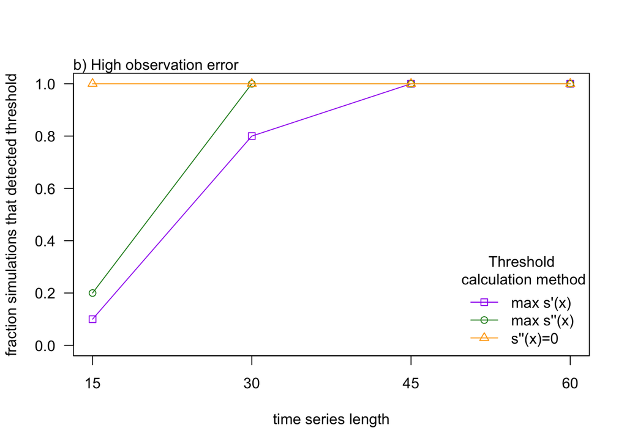

```r
# high observation error
nthresh1_totH <- c(sum(threshdiff_highOE[[1]]$thresh1df$nthresh), sum(threshdiff_highOE[[2]]$thresh1df$nthresh), sum(threshdiff_highOE[[3]]$thresh1df$nthresh), sum(threshdiff_highOE[[4]]$thresh1df$nthresh))/nsim

nthresh2_totH <- c(sum(threshdiff_highOE[[1]]$thresh2df$nthresh), sum(threshdiff_highOE[[2]]$thresh2df$nthresh), sum(threshdiff_highOE[[3]]$thresh2df$nthresh), sum(threshdiff_highOE[[4]]$thresh2df$nthresh))/nsim

nthresh20_totH <- c(sum(threshdiff_highOE[[1]]$thresh20df$nthresh), sum(threshdiff_highOE[[2]]$thresh20df$nthresh), sum(threshdiff_highOE[[3]]$thresh20df$nthresh), sum(threshdiff_highOE[[4]]$thresh20df$nthresh))/nsim



plot(x = length_set, y = nthresh1_totH, type = "o",pch = threshpch[1], ylim = c(0, 1), xaxt = "n", xlab = "time series length", ylab = "fraction simulations that detected threshold", las = 1, col = threshcols[1])
axis(side = 1, at = length_set, labels = length_set)
lines(x = length_set, y = nthresh2_totH, type = "o", pch = threshpch[2], col = threshcols[2])
lines(x = length_set, y = nthresh20_totH, type = "o", pch = threshpch[3], col = threshcols[3])
legend(x = "bottomright", legend = c("max s'(x)", "max s''(x)", "s''(x)=0"), title = "Threshold \ncalculation method", col = threshcols, pch = threshpch, lty = 1, bty = "n")
mtext(side = 3, line= 0, "b) High observation error", adj = 0)
```

When the threshold was calculated as location where second deriv is closest to zero (orange lines in the above plots), a threshold was always detected, which makes sense because unlike the other two methods, this method doesn’t have any significance criteria. For the other two methods I tried, either the first deriv (purple lines) or second deriv (green lines) needed to be significantly different from zero, which is less likely to occur when the time series is short and/or observation error is high.

For the simulations where a threshold was detected, look at the difference between the estimated threshold and the true threshold

```r
# first put everything into a data frame for plotting: need column for thresh type, and also column for level of obs error (for facet_wrap)

# low obs error
for(i in 1:length(length_set)){

  if(i == 1){

    lowOE_df <- rbind(threshdiff_lowOE[[i]]$thresh1df, threshdiff_lowOE[[i]]$thresh2df, threshdiff_lowOE[[i]]$thresh20df) %>% mutate(ts_length = as.character(length_set[i])) %>% mutate(obs_error = "low")

  } else{

    df_i <- rbind(threshdiff_lowOE[[i]]$thresh1df, threshdiff_lowOE[[i]]$thresh2df, threshdiff_lowOE[[i]]$thresh20df) %>% mutate(ts_length = as.character(length_set[i])) %>% mutate(obs_error = "low")

    lowOE_df <- rbind(lowOE_df, df_i)

  }

}

# high obs error

for(i in 1:length(length_set)){

  if(i == 1){

    highOE_df <- rbind(threshdiff_highOE[[i]]$thresh1df, threshdiff_highOE[[i]]$thresh2df, threshdiff_highOE[[i]]$thresh20df) %>% mutate(ts_length = as.character(length_set[i])) %>% mutate(obs_error = "high")

  } else{

    df_i <- rbind(threshdiff_highOE[[i]]$thresh1df, threshdiff_highOE[[i]]$thresh2df, threshdiff_highOE[[i]]$thresh20df) %>% mutate(ts_length = as.character(length_set[i])) %>% mutate(obs_error = "high")

    highOE_df <- rbind(highOE_df, df_i)

  }

}


# combine altogether
results_df <- rbind(lowOE_df, highOE_df)

#View(results_df)
```

Low observation error:

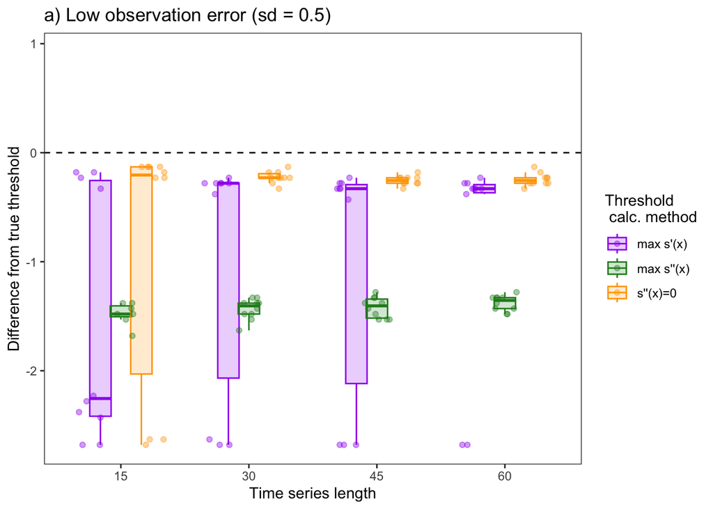

```r
results_df %>% filter(obs_error=="low") %>%
ggplot(aes(x = ts_length, y = threshdiff, fill = type, color = type)) +
  ylim(min(results_df$threshdiff, na.rm = T), max(results_df$threshdiff, na.rm = T))+
  xlab("Time series length")+
  ylab("Difference from true threshold")+
  ggtitle("a) Low observation error (sd = 0.5)")+
  geom_boxplot(outlier.shape = NA, width    = 0.5, # width of the boxes
               position = position_dodge(0.48), alpha = 0.2) + # how far apart the boxes in each subgroup are
  geom_point(position=position_jitterdodge(0.2), alpha = 0.4)+ # jittered points around each subgroup, smaller value in jitterdodge means less spread
  scale_fill_manual(name = "Threshold \n calc. method",values=threshcols, labels = c("max s'(x)", "max s''(x)", "s''(x)=0")) + # colors for fill of boxplot
  scale_color_manual(name = "Threshold \n calc. method", values=threshcols, labels = c("max s'(x)", "max s''(x)", "s''(x)=0")) + # colors for points and outline of boxplot
  geom_hline(yintercept=0, linetype="dashed", color="black")+
  theme_bw()+
  theme(panel.grid.major = element_blank(), panel.grid.minor = element_blank())#+
```

Note that for the threshold that is calculated as the location where first deriv is at a max/min and significantly different from zero (purple), there seems to be two sets of thresholds being detected, one that’s close to the true value and one that’s much farther way. Based on the plot of the smoothed first derivative, I think this second predicted threshold is where the smoothed first derivative starts to curve up slightly around x = 1.5, creating a minimum where the abs value of the first deriv is greater than at the maximum that occurs near the true threshold (and I currently have the threshold calculation function set up so that it only selects the global max/min as the value of the threshold, so this should probably be changed)

High observation error:

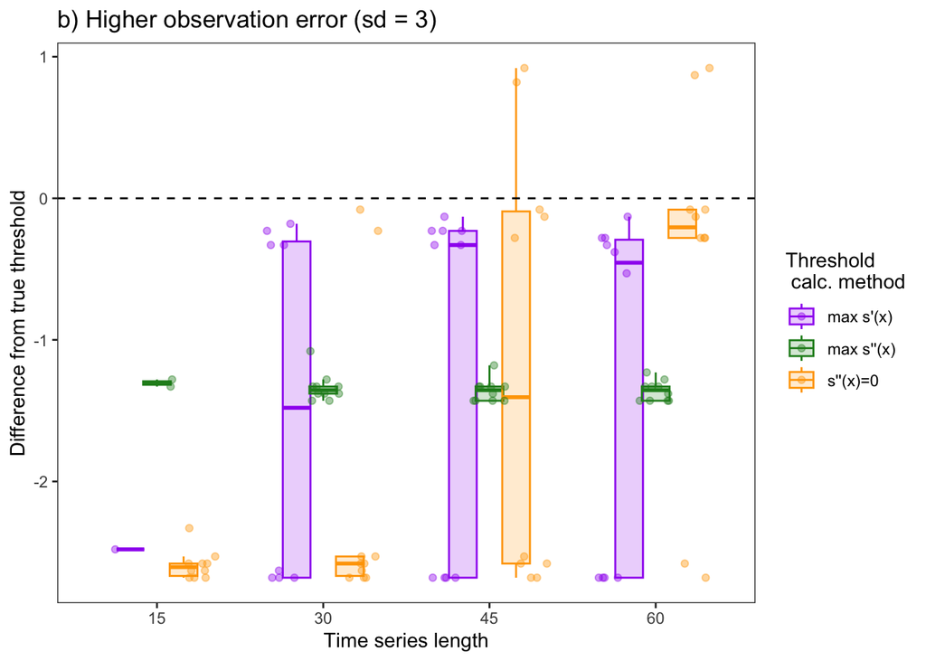

```r
results_df %>% filter(obs_error=="high") %>%
ggplot(aes(x = ts_length, y = threshdiff, fill = type, color = type)) +
  ylim(min(results_df$threshdiff, na.rm = T), max(results_df$threshdiff, na.rm = T))+
  xlab("Time series length")+
  ylab("Difference from true threshold")+
  ggtitle("b) Higher observation error (sd = 3)")+
  geom_boxplot(outlier.shape = NA, width    = 0.5, # width of the boxes
               position = position_dodge(0.48), alpha = 0.2) + # how far apart the boxes in each subgroup are
  geom_point(position=position_jitterdodge(0.2), alpha = 0.4)+ # jittered points around each subgroup, smaller value in jitterdodge means less spread
  scale_fill_manual(name = "Threshold \n calc. method",values=threshcols, labels = c("max s'(x)", "max s''(x)", "s''(x)=0")) + # colors for fill of boxplot
  scale_color_manual(name = "Threshold \n calc. method", values=threshcols, labels = c("max s'(x)", "max s''(x)", "s''(x)=0")) + # colors for points and outline of boxplot
  geom_hline(yintercept=0, linetype="dashed", color="black")+
  theme_bw()+
  theme(panel.grid.major = element_blank(), panel.grid.minor = element_blank())#+
```